# Microfinance Summary Stats

This document is for general exploration of the India Findex 2014 dataset containing survey results from 3000 participants regarding their financial habits.

# Introduction

### The objectives of microfinance institutions are:

- To ensure everyone has access to financial services
- To ensure that this access is provided fairly with due consideration given to their social circumstances
- To provide the above services below the market price with a secondary aim of helping raise the living standards of those in lower income levels.

### Literature review

Within academic literature, evidence on the impact on household lifetime wealth of microfinace services is mixed. Some studies such as Pitt and Khandker (1998) found a statistically significant positive relationship between a household’s use of credit and the value of the household assets as well as the likelihood of the children attending school in Bangladesh. However, when Knandker followed up with the subjects in the original review and conducted a second set of surveys to examine borrower behaviour over time, the relationship between credit and markets of household lifetime wealth was greatly diminished. Other studies such as Coleman (1999) examining microcredit in northern Thailand also found no significant impact of credit access to household wealth. However, Cotler and Woodruff (2017) found statistically significant impacts of microlending on the sales and profit margins of small businesses in Mexico.

In order to evaluate the impact of access to microfinace services in isolation, studies must be able to control for sampling bias. Studies such as Karlan and Zinman (2006) manage to do just that by collaborating with a South African MFI to work with randomly chosen participants from a cohort of clients who were on the borderline of loan approval but were rejected. A random selection of these applicants were granted loans and were surveyed both six months and twelve months later to observe the impact of the loan. The researchers found that the chosen borrowers were statistically significantly more likely to retain wage employment, less likely to experience hunger in their household, and less likely to be impoverished than their non-borrowing counterparts.

This report will examine the impact of interacting with financial services on low income households in India. The datasource is the 2014 Global Findex microdata which contains individual-level survey results. Low income households (defined as survey participants in the lower 2 within economy household income quintiles) have been chosen as the focus group as these are the particupants which are most likely to benefit from microfinancial services. The dependent variables are chosen based on their correlations with household lifetime wealth.

## Summary of characteristics of respondants in the sample.

The below tables provide a summary of the respondents in the sample. This includes a count of males and females, age groups, the income quintiles and access to bank accounts for the respondents.

### Gender

Although the distribution of males and females in the sample is relatively proportionate, approximately 150 more males were surveyed in the 2014 dataset in India.

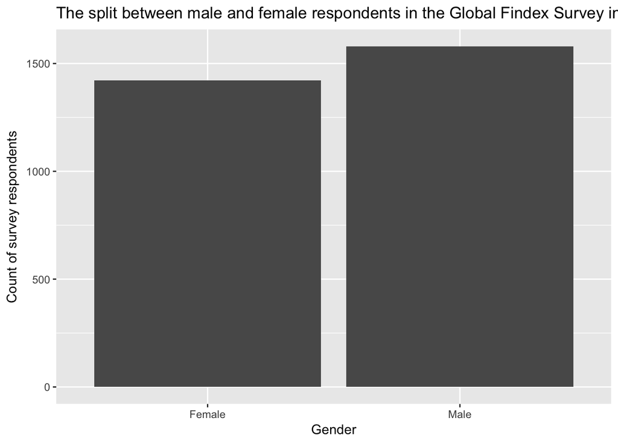

### Education

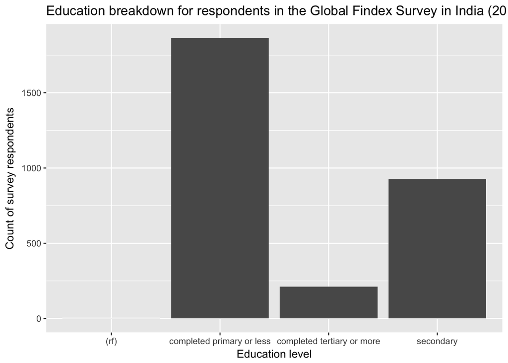

### Within economy income quintile

The distrubtion of respondents is relatively even amongst the second, third and fourth quintile. However, respondents in the poorest 20% income bracket are significantly under represented while respondents in the highest 20% income bracket are slightly over represented.

The 2014 sample dramatically under-represents people in the lowest 20% household income quintile. This is a big problem because that would have been the target demographic for microfinance, individuals with less disposable income are more likely to be denied financial services from the traditional sector so their underrepresentation in the Global Findex means that the sample is skewed. I look forward to examining the sample mix in the 2017 data to see if it’s been fixed.

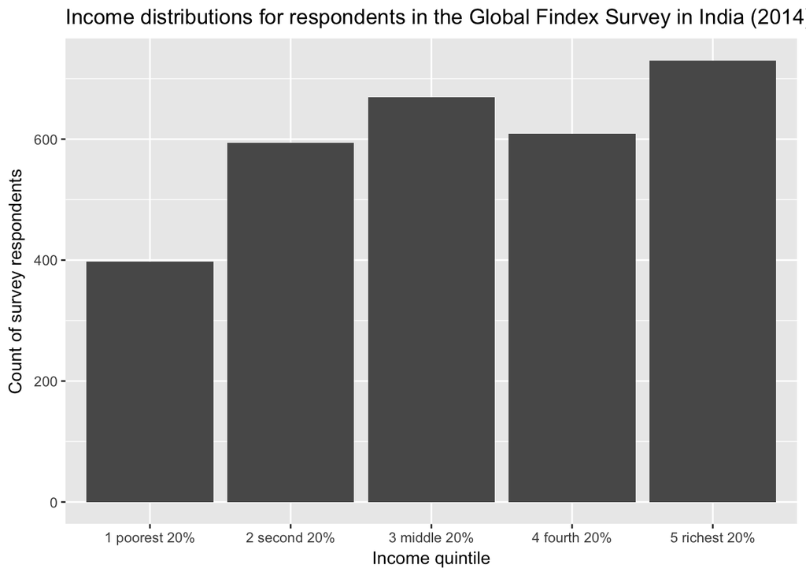

### Age of respondents

The skew of respondents is right-tailed with many more younger participants than older ones.

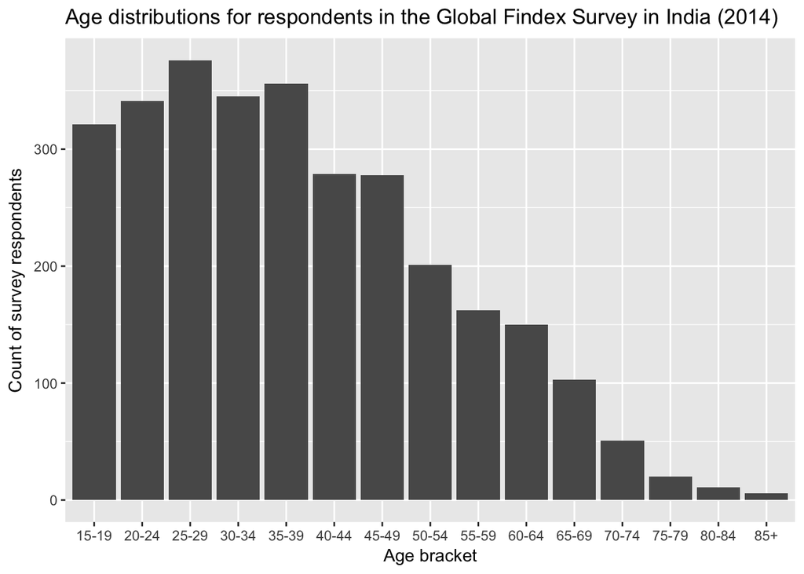

### Bank account numbers

The majority of respondents (over 55%) have a bank account.

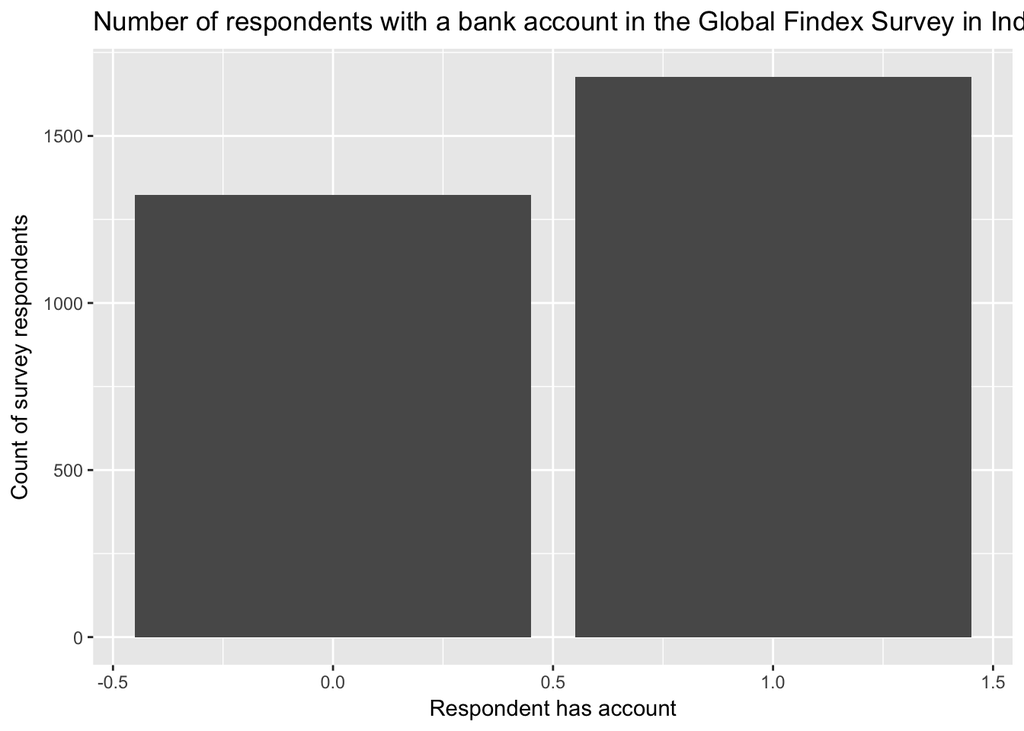

### Microfinance and income

Most microfinance institutions are targetting those in the lowest two income quintiles who might otherwise go unserved by traditional financial institutions.

Examining financial decisions made by respondents within the lowest 40% income quintiles, we see the following results.

```
## [[1]]
##        Freq      Prop
## Female  484 0.4879032
## Male    508 0.5120968
##
## [[2]]
##                            Freq      Prop
## completed primary or less   705 0.7106855
## completed tertiary or more   31 0.0312500
## secondary                   256 0.2580645
##
## [[3]]
##   Freq      Prop
## 0  513 0.5171371
## 1  479 0.4828629
##
## [[4]]
##       Freq        Prop
## 0-1      0 0.000000000
## 1-4      0 0.000000000
## 5-9      0 0.000000000
## 10-14    0 0.000000000
## 15-19  132 0.133064516
## 20-24  116 0.116935484
## 25-29  118 0.118951613
## 30-34  110 0.110887097
## 35-39  110 0.110887097
## 40-44  101 0.101814516
## 45-49   78 0.078629032
## 50-54   58 0.058467742
## 55-59   51 0.051411290
## 60-64   56 0.056451613
## 65-69   37 0.037298387
## 70-74   16 0.016129032
## 75-79    6 0.006048387
## 80-84    2 0.002016129
## 85+      1 0.001008065
```

### Income and education

Although across the total sample surveyed, 62% of respondents had primary education or less, for those earning income within the lowest 40% quintiles, this is amplied suggesting that low income earners occupy a large subset of those with primary education or less.

## Who has an account?

On the surface it seems like more people have bank accounts than not

The overall split suggests that the majority of respondents have access to banking.

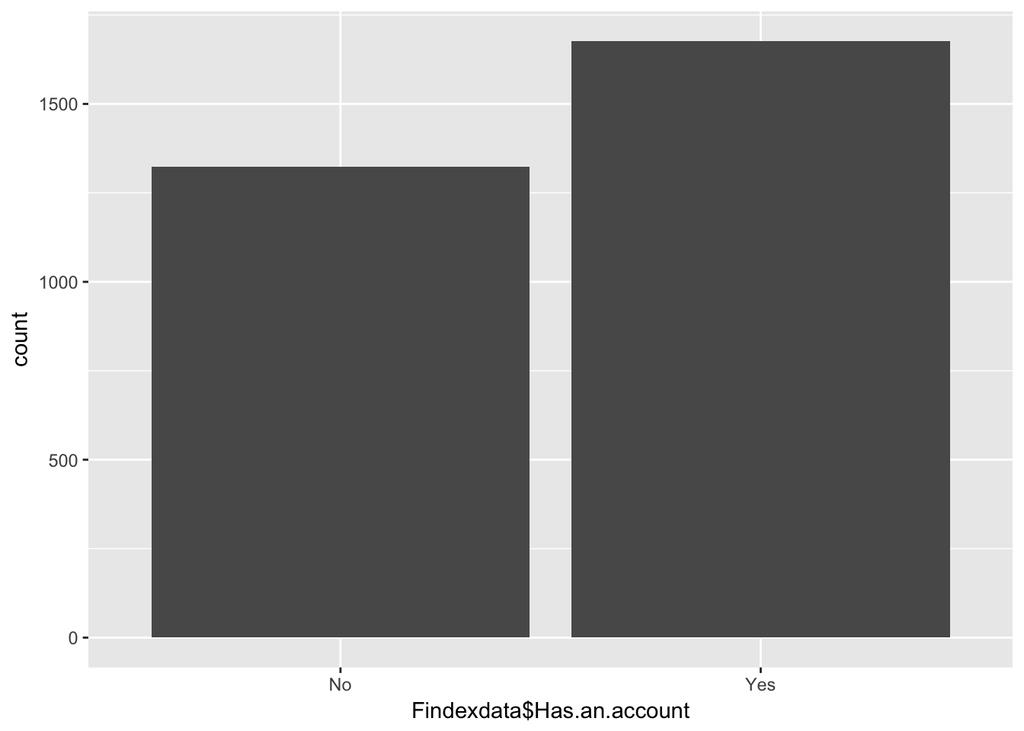

The most common reason in 2014 stated by respondents for not having an account is lack of money required to open up. MFIs must step in to bridge this financial gap.

[figure not shown]

### Income and bank account numbers

From the data, we see that examining all respondents suggests that the majority have access to banking services. However, at a closer glance at those in lower incomes this result is flipped. The majority of respondents do not have a bank accout, although the split between those who do and do not is much smaller as compared to the original sample.

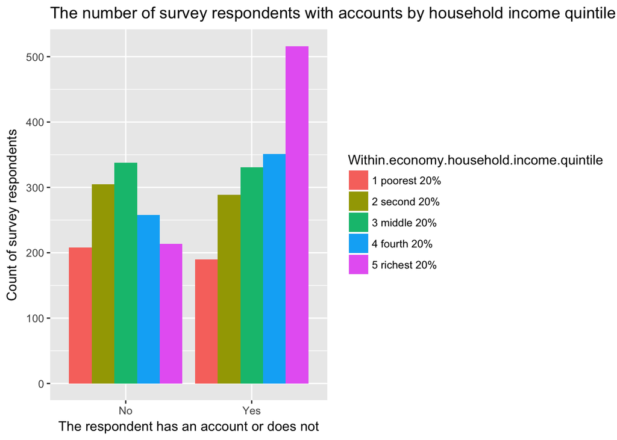

### Gender and bank account numbers

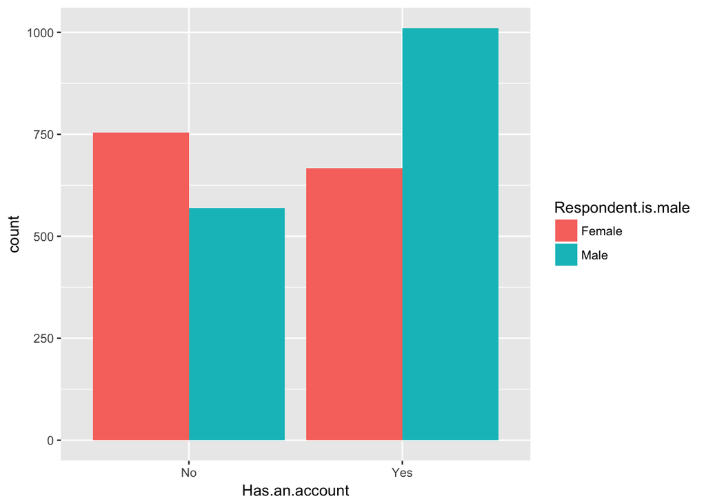

```
## [1] NaN
```

```
## [1] NaN
```

Within the lowest 20%, men are more likely to have a bank account than women:

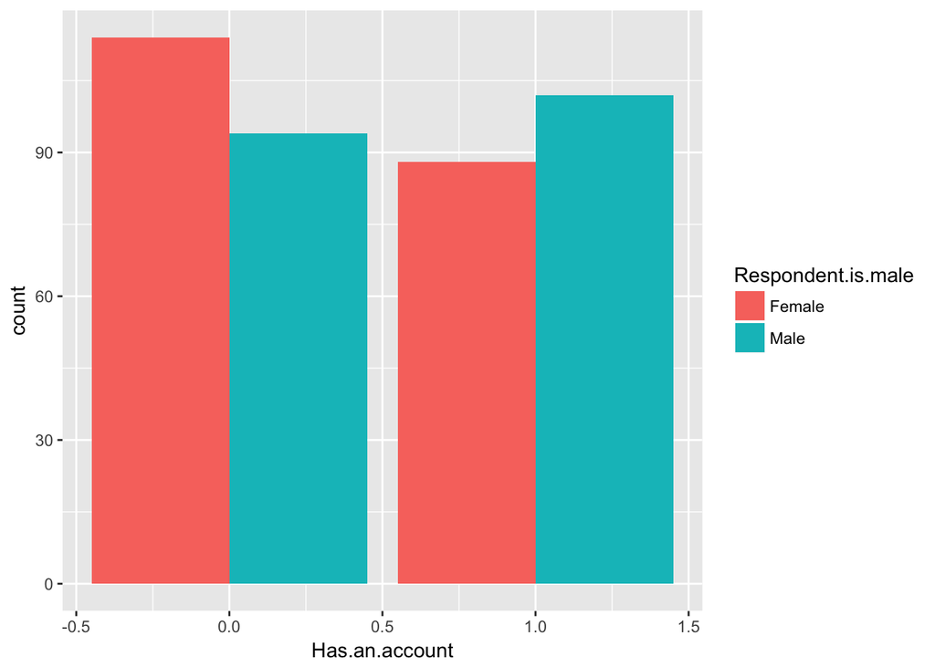

Proportion of all respondents in lowest 20% income quintile with a bank account:

```
## [1] 0.4773869
```

```
## [1] NaN
```

```
## [1] NaN
```

Under half of the women in low income brackets have bank accounts. Rates of women with bank accounts in low income households are lower than the sample average by 4pp.

## Examining differences between high income respondents in India and low income respondents.

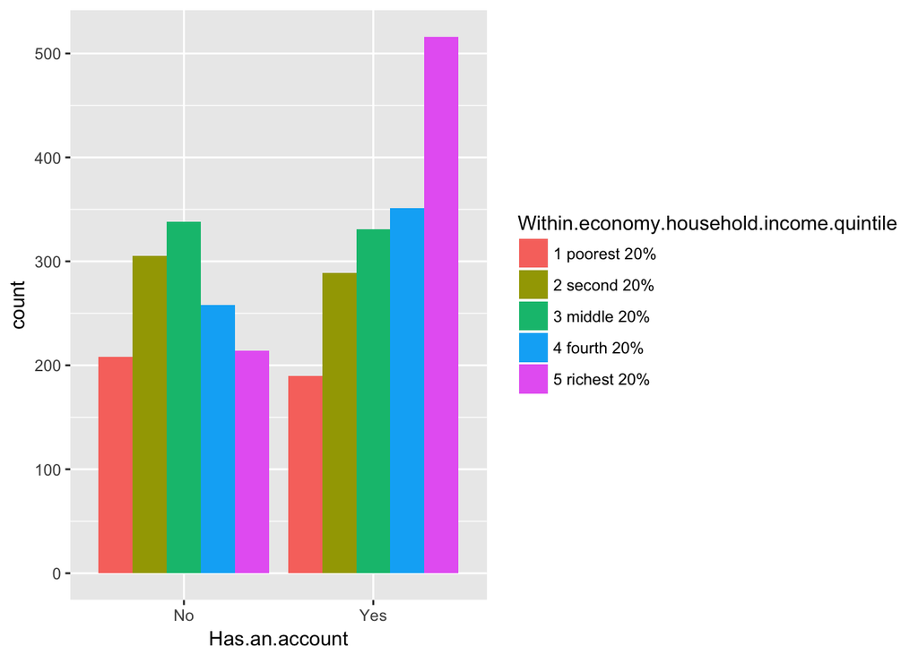

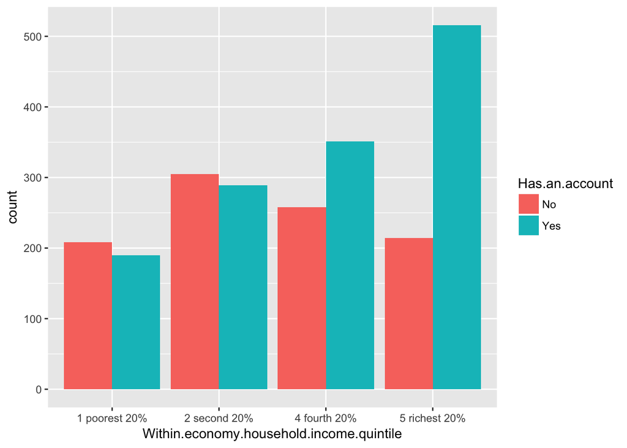

```
## [1] NaN
```

```
## [1] 0
```

```
## [1] NaN
```

```
## [1] NaN
```

# How does asset management behaviour differ amongst different people in India? Respondents show that:

## Education

The return to spending on education can vary dramatically between countries, genders and income levels. Most studies find that the return is statistically significant and varies between 8% and 13%. The analysis below examines how these characters correlate with a person’s decision to save money for education. This analysis is also extended to borrowing behaviour as a comparator.

### Income:

Proportion of low income people with an account who save for school fees:

```
## [1] 0.2473684
```

```
## [1] Inf
```

### Gender:

```
## [1] NaN
```

```
## [1] NaN
```

```
## [1] 0
```

### Income:

```
## [1] 0.2052632
```

```
## [1] Inf
```

### Gender:

```
## [1] 0
```

# Conclusion and further considerations:

To evaluate the effect of increasing financial access for households and microentrepreneurs, one has to look beyond the direct impact on the household or enterprise and assess the impact on the whole economy. That cannot be done through micro studies. In particular, even if the very poor do not themselves gain access to financial services, they may benefit substantially from increased employment and other opportunities resulting from the activities of less-poor microentrepreneurs whose access has improved. With large numbers of the nonpoor still excluded from access to credit, these systemic effects could include trickle-down effects for the poor from improved access for the nonpoor. However, they could also include perverse trickle-down effects: if only a subset of households in a village has access to credit or insurance to smooth consumption, that subset will bid up the price of nontraded goods when a negative shock hits the village, so excluded households will be worse off than if nobody had access to credit or insurance (Morduch 2006).

## Better metrics for measuring financial inclusion

The fact sheet for India in the 2017 data showed that the rate of unused banked was approximately 40% of bank accounts in the report. This means that only 32% of users in the survey (960 of the 3000) actually have an active bank account. This statistic suggests that just having a bank account is not a good enough metric by itself and there are still further challenges to go. Availability of financial markets doesn’t mean that people make the most of the services in front of them. Further analysis and data collection in MFI areas should aim to understand what barriers people might face in accessing banking and other digital financial management tools.